# H-G05-Final Project

# Part B: Data Exploration (EDA)

## B.1 — Dataset Shape, Types & Summary Statistics

```r
# ============================================================
# B.1 DATASET SHAPE AND DATA TYPES
# Shows total rows, columns and the type of each feature
# ============================================================

cat("DATASET SHAPE")
```

```
## DATASET SHAPE
```

```r
cat("Total Rows    :", nrow(df), "\n")
```

```
## Total Rows    : 814
```

```r
cat("Total Columns :", ncol(df), "\n\n")
```

```
## Total Columns : 18
```

```r
cat("=== DATA TYPES OF EACH COLUMN ===\n")
```

```
## === DATA TYPES OF EACH COLUMN ===
```

```r
for (col in colnames(df)) {
  cat(sprintf("%-35s : %s\n", col, class(df[[col]])))
}
```

```
## Nationality                         : character
## FIFA.Ranking                        : numeric
## National.Team.Kit.Sponsor           : character
## Position                            : character
## National.Team.Jersey.Number         : numeric
## Player.DOB                          : character
## Club                                : character
## Player.Name                         : character
## Appearances                         : numeric
## Goals.Scored                        : numeric
## Assists.Provided                    : numeric
## Dribbles.per.90                     : numeric
## Interceptions.per.90                : numeric
## Tackles.per.90                      : numeric
## Total.Duels.Won.per.90              : numeric
## Save.Percentage                     : numeric
## Clean.Sheets                        : numeric
## Brand.Sponsor.Brand.Used            : character
```

```r
# ============================================================
# SUMMARY STATISTICS
# Min, Max, Mean, Median for numerical features
# Length and class for categorical features
# ============================================================

cat("SUMMARY STATISTICS")
```

```
## SUMMARY STATISTICS
```

```r
summary(df)
```

```
##  Nationality         FIFA.Ranking   National.Team.Kit.Sponsor
##  Length:814         Min.   : 1.00   Length:814
##  Class :character   1st Qu.: 9.00   Class :character
##  Mode  :character   Median :18.00   Mode  :character
##                     Mean   :21.71
##                     3rd Qu.:29.00
##                     Max.   :60.00
##
##    Position         National.Team.Jersey.Number  Player.DOB
##  Length:814         Min.   : 1.00               Length:814
##  Class :character   1st Qu.: 7.00               Class :character
##  Mode  :character   Median :14.00               Mode  :character
##                     Mean   :13.51
##                     3rd Qu.:20.00
##                     Max.   :26.00
##                     NA's   :1
##      Club           Player.Name         Appearances     Goals.Scored
##  Length:814         Length:814         Min.   :0.000   Min.   :0.0000
##  Class :character   Class :character   1st Qu.:2.000   1st Qu.:0.0000
##  Mode  :character   Mode  :character   Median :3.000   Median :0.0000
##                                        Mean   :2.832   Mean   :0.2842
##                                        3rd Qu.:4.000   3rd Qu.:0.0000
##                                        Max.   :7.000   Max.   :8.0000
##                                        NA's   :153     NA's   :230
##  Assists.Provided Dribbles.per.90  Interceptions.per.90 Tackles.per.90
##  Min.   :0.0000   Min.   : 0.000   Min.   : 0.0000      Min.   : 0.000
##  1st Qu.:0.0000   1st Qu.: 0.000   1st Qu.: 0.0000      1st Qu.: 0.340
##  Median :0.0000   Median : 0.660   Median : 0.5000      Median : 1.300
##  Mean   :0.1901   Mean   : 1.224   Mean   : 0.9274      Mean   : 1.557
##  3rd Qu.:0.0000   3rd Qu.: 1.590   3rd Qu.: 1.1800      3rd Qu.: 2.250
##  Max.   :3.0000   Max.   :36.000   Max.   :68.0000      Max.   :10.800
##  NA's   :230      NA's   :251      NA's   :251          NA's   :259
##  Total.Duels.Won.per.90 Save.Percentage   Clean.Sheets
##  Min.   : 0.000         Min.   :  0.00   Min.   :  0.00
##  1st Qu.: 3.180         1st Qu.: 53.33   1st Qu.:  0.00
##  Median : 5.120         Median : 64.69   Median : 22.50
##  Mean   : 5.399         Mean   : 61.84   Mean   : 24.53
##  3rd Qu.: 7.170         3rd Qu.: 73.44   3rd Qu.: 50.00
##  Max.   :18.490         Max.   :100.00   Max.   :100.00
##  NA's   :281            NA's   :776      NA's   :776
##  Brand.Sponsor.Brand.Used
##  Length:814
##  Class :character
##  Mode  :character
##
##
##
##
```

> **Interpretation:** Most performance stats (Goals, Assists, Dribbles) have very low medians close to zero, indicating that the majority of players are defenders and midfielders with limited attacking output. The mean is pulled upward by a few standout players, confirming right-skewed distributions.

## B.2 — Identify Feature Types

```r
# ============================================================
# B.2 IDENTIFY FEATURE TYPES
# Clearly separates numerical and categorical columns
# ============================================================

# Identify numerical columns
num_cols <- names(df)[sapply(df, is.numeric)]

# Identify categorical columns
cat_cols <- names(df)[sapply(df, is.character)]

cat("NUMERICAL FEATURES (", length(num_cols), "total )")
```

```
## NUMERICAL FEATURES ( 11 total )
```

```r
for (i in seq_along(num_cols)) {
  cat(sprintf("%2d. %-35s (numeric)\n", i, num_cols[i]))
}
```

```
##  1. FIFA.Ranking                        (numeric)
##  2. National.Team.Jersey.Number         (numeric)
##  3. Appearances                         (numeric)
##  4. Goals.Scored                        (numeric)
##  5. Assists.Provided                    (numeric)
##  6. Dribbles.per.90                     (numeric)
##  7. Interceptions.per.90                (numeric)
##  8. Tackles.per.90                      (numeric)
##  9. Total.Duels.Won.per.90              (numeric)
## 10. Save.Percentage                     (numeric)
## 11. Clean.Sheets                        (numeric)
```

```r
cat("CATEGORICAL FEATURES (", length(cat_cols), "total )")
```

```
## CATEGORICAL FEATURES ( 7 total )
```

```r
for (i in seq_along(cat_cols)) {
  cat(sprintf("%2d. %-35s (character)\n", i, cat_cols[i]))
}
```

```
##  1. Nationality                         (character)
##  2. National.Team.Kit.Sponsor           (character)
##  3. Position                            (character)
##  4. Player.DOB                          (character)
##  5. Club                                (character)
##  6. Player.Name                         (character)
##  7. Brand.Sponsor.Brand.Used            (character)
```

> **Interpretation:** There are **11 numerical features** (performance metrics like Goals, Tackles, Dribbles) and **7 categorical features** (player and team information like Nationality, Position, Club). This mix makes the dataset suitable for both regression and classification tasks.

## B.3 — Missing Values Detection

```r
# ============================================================
# B.3 DETECT MISSING VALUES
# Shows count and percentage of missing values per column
# ============================================================

missing_count   <- colSums(is.na(df))
missing_percent <- round((missing_count / nrow(df)) * 100, 2)

missing_report <- data.frame(
  Column          = names(missing_count),
  Missing_Count   = as.integer(missing_count),
  Missing_Percent = paste0(missing_percent, "%")
) %>% arrange(desc(Missing_Count))

cat("MISSING VALUES REPORT")
```

```
## MISSING VALUES REPORT
```

```r
print(missing_report, row.names = FALSE)
```

```
##                       Column Missing_Count Missing_Percent
##              Save.Percentage           776          95.33%
##                 Clean.Sheets           776          95.33%
##       Total.Duels.Won.per.90           281          34.52%
##               Tackles.per.90           259          31.82%
##              Dribbles.per.90           251          30.84%
##         Interceptions.per.90           251          30.84%
##                 Goals.Scored           230          28.26%
##             Assists.Provided           230          28.26%
##                  Appearances           153           18.8%
##                         Club             2           0.25%
##     Brand.Sponsor.Brand.Used             2           0.25%
##    National.Team.Kit.Sponsor             1           0.12%
##  National.Team.Jersey.Number             1           0.12%
##                  Nationality             0              0%
##                 FIFA.Ranking             0              0%
##                     Position             0              0%
##                   Player.DOB             0              0%
##                  Player.Name             0              0%
```

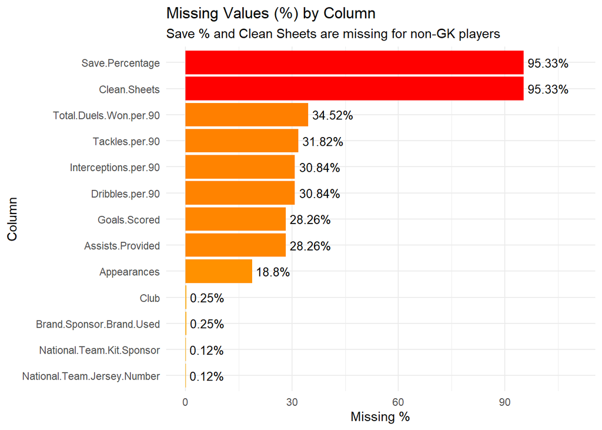

```r
# ============================================================
# MISSING VALUES BAR CHART
# Visual representation of missing percentage per column
# ============================================================

missing_plot <- data.frame(
  Column  = names(missing_count),
  Percent = as.numeric(missing_percent)
) %>%
  filter(Percent > 0) %>%
  arrange(desc(Percent))

ggplot(missing_plot, aes(x = reorder(Column, Percent),
                          y = Percent, fill = Percent)) +
  geom_bar(stat = "identity") +
  geom_text(aes(label = paste0(Percent, "%")),
            hjust = -0.1, size = 3.5) +
  coord_flip() +
  scale_fill_gradient(low = "orange", high = "red") +
  theme_minimal() +
  theme(legend.position = "none") +
  ylim(0, 110) +
  labs(
    title    = "Missing Values (%) by Column",
    subtitle = "Save % and Clean Sheets are missing for non-GK players",
    x        = "Column",
    y        = "Missing %"
  )
```

> **Interpretation:** **Save Percentage (95.3%)** and **Clean Sheets (95.3%)** are almost entirely missing because these metrics only apply to Goalkeepers — this is expected, not a data error. Goals Scored, Assists Provided, and per-90 metrics have ~28–34% missing values, mostly from players with very few appearances.

## B.4 — Distributions of Numerical Features (Univariate)

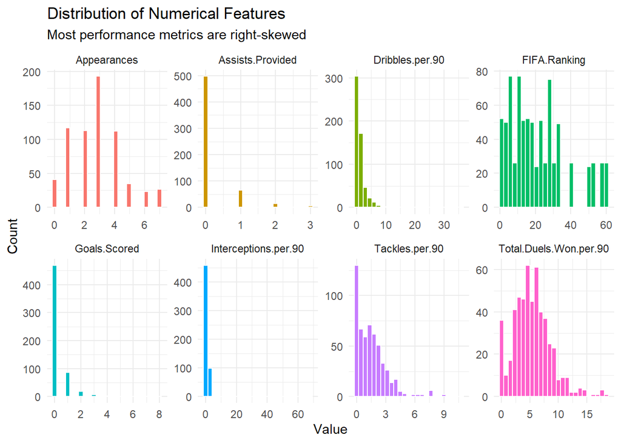

```r
# ============================================================
# B.4 HISTOGRAMS — NUMERICAL FEATURE DISTRIBUTIONS
# Shows the spread and skewness of each numeric column
# Excluding GK-only columns (Save % and Clean Sheets)
# ============================================================

plot_cols <- c("FIFA.Ranking", "Appearances", "Goals.Scored",
               "Assists.Provided", "Dribbles.per.90",
               "Interceptions.per.90", "Tackles.per.90",
               "Total.Duels.Won.per.90")

df %>%
  select(all_of(plot_cols)) %>%
  pivot_longer(everything(),
               names_to  = "Feature",
               values_to = "Value") %>%
  ggplot(aes(x = Value, fill = Feature)) +
  geom_histogram(bins = 25, color = "white", show.legend = FALSE) +
  facet_wrap(~Feature, scales = "free", ncol = 4) +
  theme_minimal() +
  labs(
    title    = "Distribution of Numerical Features",
    subtitle = "Most performance metrics are right-skewed",
    x        = "Value",
    y        = "Count"
  )
```

> **Interpretation:** Goals Scored, Assists Provided, and Dribbles per 90 are heavily right-skewed — most players have near-zero values while a few elite players have very high numbers. This suggests **log transformation** will be needed during preprocessing to reduce skewness.

## B.5 — Frequency of Categorical Features (Univariate)

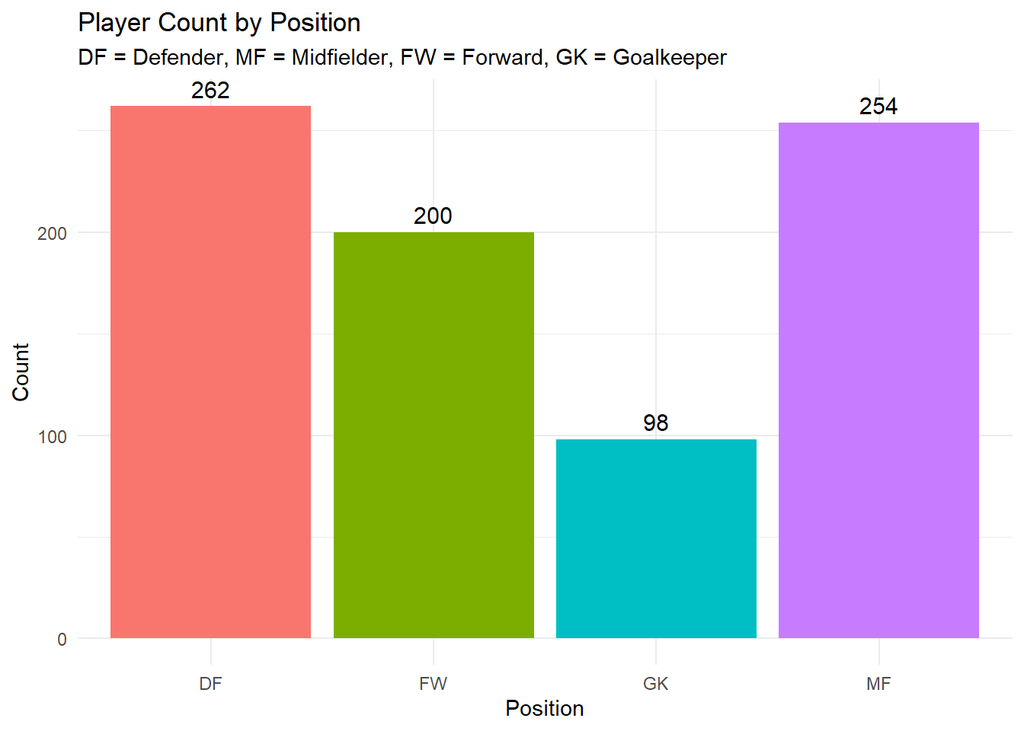

```r
# ============================================================
# B.5 CATEGORICAL FEATURE DISTRIBUTIONS
# Bar charts showing frequency of each category
# ============================================================

# --- Position Distribution ---
ggplot(df, aes(x = Position, fill = Position)) +
  geom_bar(show.legend = FALSE) +
  geom_text(stat = "count",
            aes(label = after_stat(count)),
            vjust = -0.5, size = 4) +
  theme_minimal() +
  labs(title    = "Player Count by Position",
       subtitle = "DF = Defender, MF = Midfielder, FW = Forward, GK = Goalkeeper",
       x        = "Position",
       y        = "Count")
```

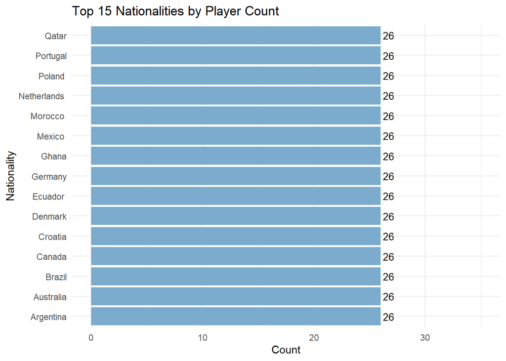

```r
# --- Top 15 Nationalities ---
df %>%
  count(Nationality, sort = TRUE) %>%
  head(15) %>%
  ggplot(aes(x = reorder(Nationality, n), y = n, fill = n)) +
  geom_bar(stat = "identity", show.legend = FALSE) +
  geom_text(aes(label = n), hjust = -0.2, size = 3.5) +
  coord_flip() +
  scale_fill_gradient(low = "lightblue", high = "steelblue") +
  theme_minimal() +
  ylim(0, 35) +
  labs(title = "Top 15 Nationalities by Player Count",
       x     = "Nationality",
       y     = "Count")
```

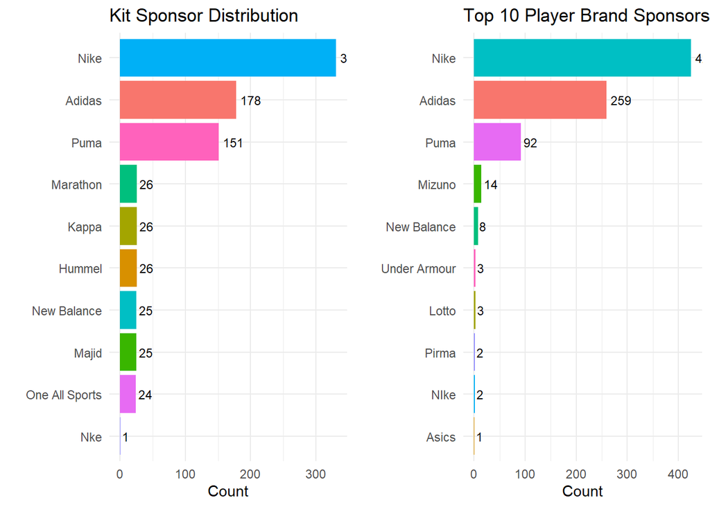

```r
# --- Kit Sponsor and Brand Sponsor ---
p1 <- df %>%
  filter(!is.na(National.Team.Kit.Sponsor)) %>%
  count(National.Team.Kit.Sponsor, sort = TRUE) %>%
  ggplot(aes(x = reorder(National.Team.Kit.Sponsor, n), y = n,
             fill = National.Team.Kit.Sponsor)) +
  geom_bar(stat = "identity", show.legend = FALSE) +
  geom_text(aes(label = n), hjust = -0.2, size = 3) +
  coord_flip() +
  theme_minimal() +
  labs(title = "Kit Sponsor Distribution",
       x = "", y = "Count")

p2 <- df %>%
  filter(!is.na(Brand.Sponsor.Brand.Used)) %>%
  count(Brand.Sponsor.Brand.Used, sort = TRUE) %>%
  head(10) %>%
  ggplot(aes(x = reorder(Brand.Sponsor.Brand.Used, n), y = n,
             fill = Brand.Sponsor.Brand.Used)) +
  geom_bar(stat = "identity", show.legend = FALSE) +
  geom_text(aes(label = n), hjust = -0.2, size = 3) +
  coord_flip() +
  theme_minimal() +
  labs(title = "Top 10 Player Brand Sponsors",
       x = "", y = "Count")

grid.arrange(p1, p2, ncol = 2)
```

## B.6 — Correlation Matrix (Bivariate)

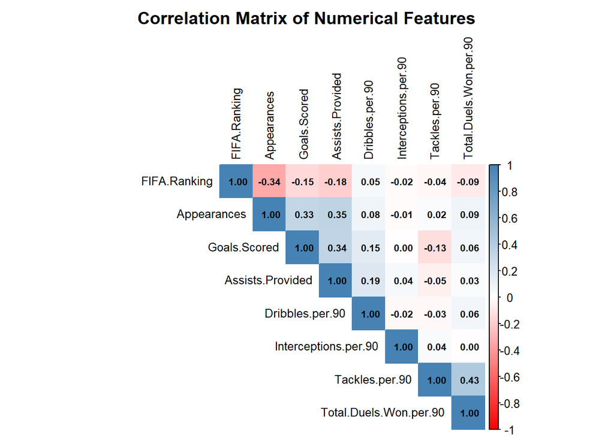

```r
# ============================================================
# B.6 CORRELATION MATRIX
# Heatmap showing linear relationships between numeric features
# Positive = blue, Negative = red, Strong = darker colour
# ============================================================

cor_cols <- c("FIFA.Ranking", "Appearances", "Goals.Scored",
              "Assists.Provided", "Dribbles.per.90",
              "Interceptions.per.90", "Tackles.per.90",
              "Total.Duels.Won.per.90")

cor_matrix <- cor(df %>% select(all_of(cor_cols)),
                  use = "complete.obs")

corrplot(
  cor_matrix,
  method      = "color",
  type        = "upper",
  tl.cex      = 0.8,
  tl.col      = "black",
  addCoef.col = "black",
  number.cex  = 0.65,
  col         = colorRampPalette(c("red", "white", "steelblue"))(200),
  title       = "Correlation Matrix of Numerical Features",
  mar         = c(0, 0, 2, 0)
)
```

## B.7 — Scatter Plots (Bivariate)

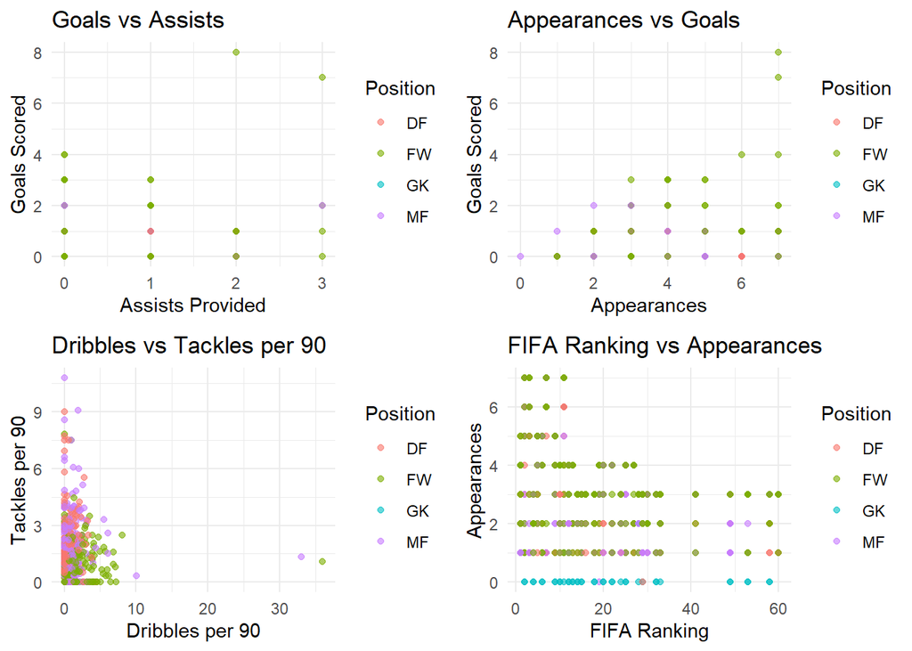

```r
# ============================================================
# B.7 SCATTER PLOTS
# Visual relationship between pairs of numeric features
# Coloured by Position for extra insight
# ============================================================

# Goals vs Assists
s1 <- df %>%
  filter(!is.na(Goals.Scored), !is.na(Assists.Provided)) %>%
  ggplot(aes(x = Assists.Provided, y = Goals.Scored, color = Position)) +
  geom_point(alpha = 0.6, size = 1.5) +
  theme_minimal() +
  labs(title = "Goals vs Assists",
       x = "Assists Provided", y = "Goals Scored")

# Appearances vs Goals
s2 <- df %>%
  filter(!is.na(Appearances), !is.na(Goals.Scored)) %>%
  ggplot(aes(x = Appearances, y = Goals.Scored, color = Position)) +
  geom_point(alpha = 0.6, size = 1.5) +
  theme_minimal() +
  labs(title = "Appearances vs Goals",
       x = "Appearances", y = "Goals Scored")

# Dribbles vs Tackles
s3 <- df %>%
  filter(!is.na(Dribbles.per.90), !is.na(Tackles.per.90)) %>%
  ggplot(aes(x = Dribbles.per.90, y = Tackles.per.90, color = Position)) +
  geom_point(alpha = 0.6, size = 1.5) +
  theme_minimal() +
  labs(title = "Dribbles vs Tackles per 90",
       x = "Dribbles per 90", y = "Tackles per 90")

# FIFA Ranking vs Appearances
s4 <- df %>%
  filter(!is.na(FIFA.Ranking), !is.na(Appearances)) %>%
  ggplot(aes(x = FIFA.Ranking, y = Appearances, color = Position)) +
  geom_point(alpha = 0.6, size = 1.5) +
  theme_minimal() +
  labs(title = "FIFA Ranking vs Appearances",
       x = "FIFA Ranking", y = "Appearances")

grid.arrange(s1, s2, s3, s4, ncol = 2)
```

> **Interpretation:** Forwards (FW) cluster in high Goals + high Assists zones. Defenders (DF) show high Tackles and low Dribbles while Forwards show the reverse. Players from top-ranked nations (low FIFA Ranking number) tend to have more appearances, suggesting established squads give experienced players more game time.

## B.8 — Boxplots by Position (Bivariate)

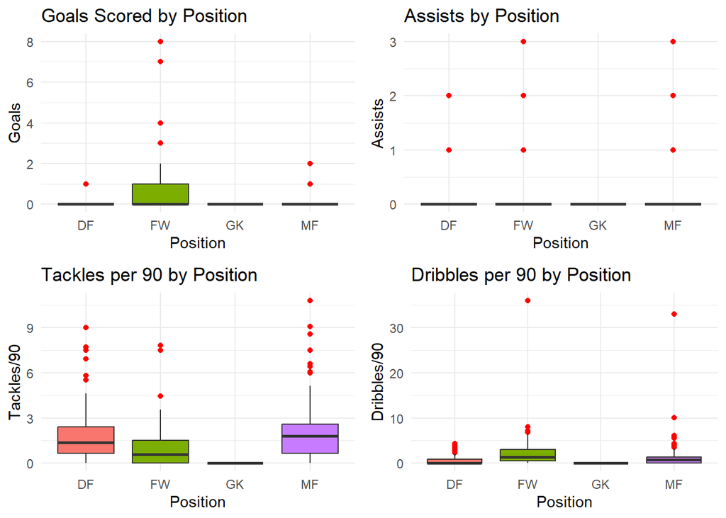

```r
# ============================================================
# B.8 BOXPLOTS — NUMERIC FEATURES BY POSITION
# Shows how performance metrics differ across positions
# ============================================================

b1 <- df %>% filter(!is.na(Goals.Scored)) %>%
  ggplot(aes(x = Position, y = Goals.Scored, fill = Position)) +
  geom_boxplot(show.legend = FALSE, outlier.colour = "red") +
  theme_minimal() +
  labs(title = "Goals Scored by Position",
       x = "Position", y = "Goals")

b2 <- df %>% filter(!is.na(Assists.Provided)) %>%
  ggplot(aes(x = Position, y = Assists.Provided, fill = Position)) +
  geom_boxplot(show.legend = FALSE, outlier.colour = "red") +
  theme_minimal() +
  labs(title = "Assists by Position",
       x = "Position", y = "Assists")

b3 <- df %>% filter(!is.na(Tackles.per.90)) %>%
  ggplot(aes(x = Position, y = Tackles.per.90, fill = Position)) +
  geom_boxplot(show.legend = FALSE, outlier.colour = "red") +
  theme_minimal() +
  labs(title = "Tackles per 90 by Position",
       x = "Position", y = "Tackles/90")

b4 <- df %>% filter(!is.na(Dribbles.per.90)) %>%
  ggplot(aes(x = Position, y = Dribbles.per.90, fill = Position)) +
  geom_boxplot(show.legend = FALSE, outlier.colour = "red") +
  theme_minimal() +
  labs(title = "Dribbles per 90 by Position",
       x = "Position", y = "Dribbles/90")

grid.arrange(b1, b2, b3, b4, ncol = 2)
```

## B.9 — Outlier Detection

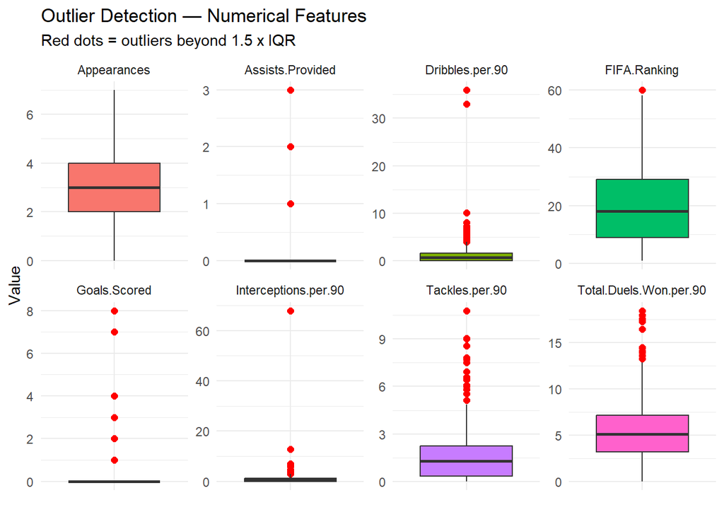

```r
# ============================================================
# B.9 OUTLIER DETECTION
# Boxplots to visualise extreme values in numeric columns
# Red dots = values beyond 1.5 x IQR (potential outliers)
# ============================================================

df %>%
  select(all_of(plot_cols)) %>%
  pivot_longer(everything(),
               names_to  = "Feature",
               values_to = "Value") %>%
  ggplot(aes(x = Feature, y = Value, fill = Feature)) +
  geom_boxplot(outlier.colour = "red",
               outlier.size   = 2,
               show.legend    = FALSE) +
  facet_wrap(~Feature, scales = "free", ncol = 4) +
  theme_minimal() +
  theme(axis.text.x = element_blank()) +
  labs(
    title    = "Outlier Detection — Numerical Features",
    subtitle = "Red dots = outliers beyond 1.5 x IQR",
    x        = "",
    y        = "Value"
  )
```

# Part C: Data Preprocessing

## C.1 — Create Preprocessing Dataset

```r
# ============================================================
# C.1 CREATE PREPROCESSING DATASET
# ============================================================
# In this section, we create a separate copy of the original dataset.
# This is important because we do not want to modify the original df
# that was used for data collection and EDA.
#
# Selected Task     : Classification
# Target Variable   : Position
# Project Objective : Predict a player's position using performance stats
# ============================================================

# Create a copy of the original dataset
processed_df <- df

# Display initial size of the preprocessing dataset
cat("Preprocessing dataset created successfully.\n")
```

```
## Preprocessing dataset created successfully.
```

```r
cat("Initial Rows    :", nrow(processed_df), "\n")
```

```
## Initial Rows    : 814
```

```r
cat("Initial Columns :", ncol(processed_df), "\n")
```

```
## Initial Columns : 18
```

```r
# Check the first few rows
head(processed_df)
```

```
##   Nationality FIFA.Ranking National.Team.Kit.Sponsor Position
## 1   Argentina            2                    Adidas       GK
## 2   Argentina            2                    Adidas       GK
## 3   Argentina            2                    Adidas       GK
## 4   Argentina            2                    Adidas       DF
## 5   Argentina            2                    Adidas       DF
## 6   Argentina            2                    Adidas       DF
##   National.Team.Jersey.Number   Player.DOB        Club        Player.Name
## 1                          23  Sep 2, 1992 Aston Villa  Emiliano Martinez
## 2                           1 Oct 16, 1986       River      Franco Armani
## 3                          12 May 20, 1992  Villarreal     Geronimo Rulli
## 4                          19 Feb 12, 1988     Benfica   Nicolas Otamendi
## 5                           8 Oct 28, 1991     Sevilla       Marcos Acuna
## 6                           3 Aug 31, 1992        Lyon Nicolas Tagliafico
##   Appearances Goals.Scored Assists.Provided Dribbles.per.90
```

[output cut: 20 more lines]

> **Interpretation:** A separate copy named `processed_df` was created from the original dataset `df`. This allows preprocessing steps to be applied safely without changing the original dataset used in Part A and Part B. The selected machine learning task is classification, where the target variable is `Position`.

## C.2 — Remove Unnecessary Columns

```r
# ============================================================
# C.2 REMOVE UNNECESSARY COLUMNS
# ============================================================
# Some columns are not suitable for model building.
#
# Full.Name:
#   This is only an identifier and does not help predict position.
#
# National.Team.Jersey.Number:
#   Jersey number is not a reliable performance-based predictor.
#
# Save.Percentage and Clean.Sheets:
#   These columns mostly apply only to Goalkeepers and contain very high
#   missing values for other positions.
# ============================================================

columns_to_remove <- c(
  "Full.Name",
  "National.Team.Jersey.Number",
  "Save.Percentage",
  "Clean.Sheets"
)

# Remove only those columns that actually exist in the dataset
processed_df <- processed_df %>%
  select(-any_of(columns_to_remove))

cat("Columns removed from the modeling dataset:\n")
```

```
## Columns removed from the modeling dataset:
```

```r
print(columns_to_remove)
```

```
## [1] "Full.Name"                   "National.Team.Jersey.Number"
## [3] "Save.Percentage"             "Clean.Sheets"
```

```r
cat("\nRows after column removal    :", nrow(processed_df), "\n")
```

```
##
## Rows after column removal    : 814
```

```r
cat("Columns after column removal :", ncol(processed_df), "\n")
```

```
## Columns after column removal : 15
```

## C.3 — Remove Missing Target Values

```r
# ============================================================
# C.3 REMOVE MISSING TARGET VALUES
# ============================================================
# Since Position is the target variable, rows with missing Position
# cannot be used for supervised classification.
# ============================================================

processed_df <- processed_df %>%
  filter(!is.na(Position))

# Convert target variable to factor
processed_df$Position <- as.factor(processed_df$Position)

cat("Rows after removing missing target values:", nrow(processed_df), "\n")
```

```
## Rows after removing missing target values: 814
```

```r
cat("\nTarget variable levels:\n")
```

```
##
## Target variable levels:
```

```r
print(levels(processed_df$Position))
```

```
## [1] "DF" "FW" "GK" "MF"
```

```r
cat("\nClass distribution of target variable:\n")
```

```
##
## Class distribution of target variable:
```

```r
print(table(processed_df$Position))
```

```
##
##  DF  FW  GK  MF
## 262 200  98 254
```

> **Interpretation:** Rows with missing `Position` values were removed because the model needs a known target label during training. The `Position` column was converted into a factor because classification models in R require the target variable to be categorical.

## C.4 — Reduce High-Cardinality Categorical Variables

```r
# ============================================================
# C.4 REDUCE HIGH-CARDINALITY CATEGORICAL VARIABLES
# ============================================================
# Some categorical variables may have many unique values.
# For example, Club, Nationality, and Brand Sponsor can create too many
# dummy variables during encoding.
#
# To reduce complexity:
# - Keep the most frequent categories
# - Group less frequent categories into "Other"
# ============================================================

reduce_categories <- function(x, top_n = 15) {

  # Convert to character so values can be edited
  x <- as.character(x)

  # Find the most frequent categories
  top_categories <- names(sort(table(x), decreasing = TRUE))[1:min(top_n, length(unique(x)))]

  # Replace all less frequent categories with "Other"
  x[!(x %in% top_categories)] <- "Other"

  # Return as factor
  return(as.factor(x))
}

# Reduce categories for selected high-cardinality columns
if ("Club" %in% names(processed_df)) {
  processed_df$Club <- reduce_categories(processed_df$Club, top_n = 15)
}

if ("Nationality" %in% names(processed_df)) {
  processed_df$Nationality <- reduce_categories(processed_df$Nationality, top_n = 15)
}

if ("Brand.Sponsor.Brand.Used" %in% names(processed_df)) {
  processed_df$Brand.Sponsor.Brand.Used <- reduce_categories(processed_df$Brand.Sponsor.Brand.Used, top_n = 10)
}

cat("High-cardinality categorical variables reduced successfully.\n")
```

```
## High-cardinality categorical variables reduced successfully.
```

```r
# Display number of unique categories after reduction
cat("\nUnique values after reduction:\n")
```

```
##
## Unique values after reduction:
```

```r
if ("Club" %in% names(processed_df)) {
  cat("Club:", length(unique(processed_df$Club)), "\n")
}
```

```
## Club: 16
```

```r
if ("Nationality" %in% names(processed_df)) {
  cat("Nationality:", length(unique(processed_df$Nationality)), "\n")
}
```

```
## Nationality: 16
```

```r
if ("Brand.Sponsor.Brand.Used" %in% names(processed_df)) {
  cat("Brand Sponsor:", length(unique(processed_df$Brand.Sponsor.Brand.Used)), "\n")
}
```

```
## Brand Sponsor: 11
```

> **Interpretation:** High-cardinality categorical variables were simplified by keeping only the most frequent categories and grouping the rest as `Other`. This prevents the model from creating too many dummy variables and helps improve readability, efficiency, and generalization.

## C.5 — Train-Test Split

```r
# ============================================================
# C.5 TRAIN-TEST SPLIT
# ============================================================
# The dataset is divided into:
# - 80% training data
# - 20% testing data
#
# createDataPartition() is used because it maintains the class distribution
# of the target variable Position in both training and testing datasets.
# ============================================================

set.seed(42)

train_index <- createDataPartition(
  processed_df$Position,
  p = 0.80,
  list = FALSE
)

train_data <- processed_df[train_index, ]
test_data  <- processed_df[-train_index, ]

cat("Training Rows:", nrow(train_data), "\n")
```

```
## Training Rows: 653
```

```r
cat("Testing Rows :", nrow(test_data), "\n")
```

```
## Testing Rows : 161
```

```r
cat("\nClass distribution in training data:\n")
```

```
##
## Class distribution in training data:
```

```r
print(table(train_data$Position))
```

```
##
##  DF  FW  GK  MF
## 210 160  79 204
```

```r
cat("\nClass distribution in testing data:\n")
```

```
##
## Class distribution in testing data:
```

```r
print(table(test_data$Position))
```

```
##
## DF FW GK MF
## 52 40 19 50
```

> **Interpretation:** The dataset was split into training and testing sets using an 80:20 ratio. The training set is used to build the model, while the testing set is used to evaluate performance on unseen data. Stratified splitting helps keep the position distribution similar in both sets.

## C.6 — Handle Missing Values

```r
# ============================================================
# C.6 HANDLE MISSING VALUES
# ============================================================
# Missing values are handled separately for numerical and categorical columns.
#
# Numerical columns:
#   Missing values are replaced with the median from the training data.
#   Median is better than mean here because football statistics are skewed.
#
# Categorical columns:
#   Missing values are replaced with the mode from the training data.
#
# Important:
#   Imputation values are calculated from training data only and then applied
#   to both training and testing data. This prevents data leakage.
# ============================================================

# Identify numerical columns
numeric_cols <- names(train_data)[sapply(train_data, is.numeric)]

# Identify categorical predictor columns
categorical_cols <- names(train_data)[sapply(train_data, function(x) {
  is.character(x) | is.factor(x)
})]

# Remove target variable from categorical predictor list
categorical_cols <- setdiff(categorical_cols, "Position")

# Function to calculate mode
get_mode <- function(x) {
  x <- x[!is.na(x)]
  ux <- unique(x)
  ux[which.max(tabulate(match(x, ux)))]
}

# Impute missing values in numerical columns
for (col in numeric_cols) {

  train_median <- median(train_data[[col]], na.rm = TRUE)

  train_data[[col]][is.na(train_data[[col]])] <- train_median
  test_data[[col]][is.na(test_data[[col]])]   <- train_median
}

# Impute missing values in categorical columns
for (col in categorical_cols) {

  train_mode <- get_mode(train_data[[col]])

  train_data[[col]][is.na(train_data[[col]])] <- train_mode
  test_data[[col]][is.na(test_data[[col]])]   <- train_mode
}

cat("Missing values after imputation:\n")
```

```
## Missing values after imputation:
```

```r
cat("Training Data Missing Values:", sum(is.na(train_data)), "\n")
```

```
## Training Data Missing Values: 0
```

```r
cat("Testing Data Missing Values :", sum(is.na(test_data)), "\n")
```

```
## Testing Data Missing Values : 0
```

> **Interpretation:** Missing numerical values were replaced using the median because many football performance variables are skewed. Missing categorical values were replaced using the mode, which represents the most common category. The imputation values were calculated from the training data only to avoid data leakage.

## C.7 — Handle Outliers Using IQR Capping

```r
# ============================================================
# C.7 HANDLE OUTLIERS USING IQR CAPPING
# ============================================================
# In sports datasets, extreme values may represent real elite performance.
# Therefore, outliers are capped instead of removed.
#
# IQR Method:
# Lower Bound = Q1 - 1.5 * IQR
# Upper Bound = Q3 + 1.5 * IQR
#
# Important:
# If IQR = 0, the column is skipped.
# This prevents sparse variables like Goals and Assists from being
# incorrectly capped to zero.
#
# Bounds are calculated using training data only and applied to both
# training and testing data to prevent data leakage.
# ============================================================

capped_columns <- c()
skipped_columns <- c()

for (col in numeric_cols) {

  Q1 <- quantile(train_data[[col]], 0.25, na.rm = TRUE)
  Q3 <- quantile(train_data[[col]], 0.75, na.rm = TRUE)
  IQR_value <- Q3 - Q1

  # Skip capping if IQR is zero
  if (IQR_value == 0) {
    skipped_columns <- c(skipped_columns, col)
    next
  }

  lower_bound <- Q1 - 1.5 * IQR_value
  upper_bound <- Q3 + 1.5 * IQR_value

  # Cap training data
  train_data[[col]][train_data[[col]] < lower_bound] <- lower_bound
  train_data[[col]][train_data[[col]] > upper_bound] <- upper_bound

  # Cap testing data using training bounds
  test_data[[col]][test_data[[col]] < lower_bound] <- lower_bound
  test_data[[col]][test_data[[col]] > upper_bound] <- upper_bound

  capped_columns <- c(capped_columns, col)
}

cat("Outlier capping completed using the IQR method.\n")
```

```
## Outlier capping completed using the IQR method.
```

```r
cat("\nColumns capped:\n")
```

```
##
## Columns capped:
```

```r
print(capped_columns)
```

```
## [1] "FIFA.Ranking"           "Appearances"            "Dribbles.per.90"
## [4] "Interceptions.per.90"   "Tackles.per.90"         "Total.Duels.Won.per.90"
```

```r
cat("\nColumns skipped because IQR = 0:\n")
```

```
##
## Columns skipped because IQR = 0:
```

```r
print(skipped_columns)
```

```
## [1] "Goals.Scored"     "Assists.Provided"
```

> **Interpretation:** Outliers were capped using the IQR method instead of being removed. This is suitable for football data because extreme values may represent star players or exceptional performances rather than errors. Columns with IQR equal to zero were skipped to avoid incorrectly changing useful sparse variables such as goals or assists. This preserves important football performance information while still reducing the influence of extreme values where appropriate.

## C.8 — Reduce Skewness Using Log Transformation

```r
# ============================================================
# C.8 REDUCE SKEWNESS USING LOG TRANSFORMATION
# ============================================================
# Many football statistics such as goals and assists are right-skewed.
# Most players have low values, while a few players have high values.
#
# log1p(x) is used because it safely handles zero values:
# log1p(x) = log(1 + x)
#
# New transformed features are created rather than replacing original columns.
# ============================================================

skewed_cols <- c(
  "Goals.Scored",
  "Assists.Provided",
  "Dribbles.per.90",
  "Interceptions.per.90",
  "Tackles.per.90",
  "Total.Duels.Won.per.90"
)

for (col in skewed_cols) {

  if (col %in% names(train_data)) {

    train_data[[paste0(col, "_log")]] <- log1p(train_data[[col]])
    test_data[[paste0(col, "_log")]]  <- log1p(test_data[[col]])
  }
}

cat("Log transformation completed for skewed numerical features.\n")
```

```
## Log transformation completed for skewed numerical features.
```

```r
cat("\nLog-transformed columns created:\n")
```

```
##
## Log-transformed columns created:
```

```r
print(paste0(skewed_cols, "_log"))
```

```
## [1] "Goals.Scored_log"           "Assists.Provided_log"
## [3] "Dribbles.per.90_log"        "Interceptions.per.90_log"
## [5] "Tackles.per.90_log"         "Total.Duels.Won.per.90_log"
```

> **Interpretation:** Log transformation was applied to skewed football performance variables such as goals, assists, dribbles, tackles, and interceptions. This reduces the effect of highly skewed distributions and helps the model learn patterns more effectively.Goalkeepers may be identified well because their general playing statistics differ from outfield players, although goalkeeper-specific features such as Save Percentage and Clean Sheets were removed before modeling due to high missingness.

## C.9 — Feature Engineering

```r
# ============================================================
# C.9 FEATURE ENGINEERING
# ============================================================
# Feature engineering creates new meaningful variables from existing data.
#
# Goal_Assist_Total:
#   Total direct attacking contribution.
#
# Defensive_Total:
#   Combined defensive activity using tackles and interceptions.
#
# Attack_Defense_Ratio:
#   Compares attacking contribution to defensive contribution.
#   Adding 1 prevents division by zero.
# ============================================================

train_data <- train_data %>%
  mutate(
    Goal_Assist_Total = Goals.Scored + Assists.Provided,
    Defensive_Total = Tackles.per.90 + Interceptions.per.90,
    Attack_Defense_Ratio = Goal_Assist_Total / (Defensive_Total + 1)
  )

test_data <- test_data %>%
  mutate(
    Goal_Assist_Total = Goals.Scored + Assists.Provided,
    Defensive_Total = Tackles.per.90 + Interceptions.per.90,
    Attack_Defense_Ratio = Goal_Assist_Total / (Defensive_Total + 1)
  )

cat("Feature engineering completed successfully.\n")
```

```
## Feature engineering completed successfully.
```

```r
cat("New features added:\n")
```

```
## New features added:
```

```r
cat("1. Goal_Assist_Total\n")
```

```
## 1. Goal_Assist_Total
```

```r
cat("2. Defensive_Total\n")
```

```
## 2. Defensive_Total
```

```r
cat("3. Attack_Defense_Ratio\n")
```

```
## 3. Attack_Defense_Ratio
```

```r
head(train_data[, c("Goal_Assist_Total", "Defensive_Total", "Attack_Defense_Ratio")])
```

```
##   Goal_Assist_Total Defensive_Total Attack_Defense_Ratio
## 1                 0           0.000            0.0000000
## 3                 0           1.815            0.0000000
## 4                 1           2.470            0.2881844
## 5                 0           3.380            0.0000000
## 6                 0           3.765            0.0000000
## 7                 0           0.000            0.0000000
```

> **Interpretation:** Three new football-related features were created. `Goal_Assist_Total` measures attacking contribution, `Defensive_Total` measures defensive activity, and `Attack_Defense_Ratio` compares attacking and defensive contribution. These features are meaningful because different positions have different playing responsibilities.

## C.10 — Encode Categorical Variables

```r
# ============================================================
# C.10 ENCODE CATEGORICAL VARIABLES
# ============================================================
# Machine learning models require numerical input.
# Therefore, categorical predictor variables are converted into dummy variables.
#
# The target variable Position is not encoded as a predictor because it is
# the class label we want to predict.
# ============================================================

# Recalculate categorical predictor columns after previous steps
categorical_cols <- names(train_data)[sapply(train_data, function(x) {
  is.character(x) | is.factor(x)
})]

categorical_cols <- setdiff(categorical_cols, "Position")

# Convert categorical predictors to factor
for (col in categorical_cols) {

  train_data[[col]] <- as.factor(train_data[[col]])
  test_data[[col]]  <- as.factor(test_data[[col]])

  # Ensure test data uses the same factor levels as training data
  test_data[[col]] <- factor(test_data[[col]], levels = levels(train_data[[col]]))
}

# Create dummy variable model using training data
dummy_model <- dummyVars(
  Position ~ .,
  data = train_data,
  fullRank = TRUE
)

# Apply dummy variable transformation
train_encoded <- predict(dummy_model, newdata = train_data)
test_encoded  <- predict(dummy_model, newdata = test_data)

# Convert encoded matrices to data frames
train_encoded <- as.data.frame(train_encoded)
test_encoded  <- as.data.frame(test_encoded)

# Replace any remaining NA values with 0
train_encoded[is.na(train_encoded)] <- 0
test_encoded[is.na(test_encoded)]   <- 0

cat("Categorical encoding completed successfully.\n")
```

```
## Categorical encoding completed successfully.
```

```r
cat("Training encoded columns:", ncol(train_encoded), "\n")
```

```
## Training encoded columns: 1343
```

```r
cat("Testing encoded columns :", ncol(test_encoded), "\n")
```

```
## Testing encoded columns : 1343
```

> **Interpretation:** Categorical predictors were converted into dummy variables so they could be used by the machine learning model. The target variable `Position` was excluded from encoding as a predictor because it is the output variable that the model will predict.

## C.11 — Remove Near-Zero Variance Features

```r
# ============================================================
# C.11 REMOVE NEAR-ZERO VARIANCE FEATURES
# ============================================================
# Some encoded variables may have almost the same value for all rows.
# These variables provide little useful information for the model.
# nearZeroVar() identifies and removes such features.
# ============================================================

nzv_cols <- nearZeroVar(train_encoded)

if (length(nzv_cols) > 0) {
  train_encoded <- train_encoded[, -nzv_cols, drop = FALSE]
  test_encoded  <- test_encoded[, -nzv_cols, drop = FALSE]
}

cat("Near-zero variance feature removal completed.\n")
```

```
## Near-zero variance feature removal completed.
```

```r
cat("Number of near-zero variance columns removed:", length(nzv_cols), "\n")
```

```
## Number of near-zero variance columns removed: 1320
```

```r
cat("\nColumns remaining after removal:", ncol(train_encoded), "\n")
```

```
##
## Columns remaining after removal: 23
```

> **Interpretation:** Near-zero variance features were removed because they do not provide meaningful information for classification. Removing these variables makes the model simpler and can improve performance.

## C.12 — Standardize Numerical Features

```r
# ============================================================
# C.12 STANDARDIZE NUMERICAL FEATURES
# ============================================================
# Standardization transforms features so that:
# Mean = 0
# Standard Deviation = 1
#
# Scaling is calculated from the training data only and then applied to
# the testing data. This prevents data leakage.
# ============================================================

# Note:
# Random Forest does not strictly require feature scaling because it is
# a tree-based model. However, standardization is included because the
# final project guideline requires normalization/standardization, and it
# also keeps the dataset ready for other machine learning models.

scaling_model <- preProcess(
  train_encoded,
  method = c("center", "scale")
)

train_scaled <- predict(scaling_model, train_encoded)
test_scaled  <- predict(scaling_model, test_encoded)

cat("Standardization completed successfully.\n")
```

```
## Standardization completed successfully.
```

```r
# Create final training and testing datasets
final_train <- data.frame(
  Position = train_data$Position,
  train_scaled,
  check.names = TRUE
)

final_test <- data.frame(
  Position = test_data$Position,
  test_scaled,
  check.names = TRUE
)

cat("\nFinal training dataset:\n")
```

```
##
## Final training dataset:
```

```r
cat("Rows    :", nrow(final_train), "\n")
```

```
## Rows    : 653
```

```r
cat("Columns :", ncol(final_train), "\n")
```

```
## Columns : 24
```

```r
cat("\nFinal testing dataset:\n")
```

```
##
## Final testing dataset:
```

```r
cat("Rows    :", nrow(final_test), "\n")
```

```
## Rows    : 161
```

```r
cat("Columns :", ncol(final_test), "\n")
```

```
## Columns : 24
```

```r
cat("\nMissing values in final training data:", sum(is.na(final_train)), "\n")
```

```
##
## Missing values in final training data: 0
```

```r
cat("Missing values in final testing data :", sum(is.na(final_test)), "\n")
```

```
## Missing values in final testing data : 0
```

> **Interpretation:** All predictor variables were standardized so that they have a mean of 0 and a standard deviation of 1. This ensures that variables with larger numerical ranges do not dominate the model. The final processed datasets, `final_train` and `final_test`, are now ready for modeling.

# Part D: Modeling and Evaluation

## D.1 — Model Selection

```r
# ============================================================
# D.1 MODEL SELECTION
# ============================================================
# The selected machine learning task is Classification.
#
# Target Variable : Position
# Model Selected  : Random Forest
#
# Random Forest is chosen because:
# 1. It works well for classification problems.
# 2. It can handle many predictor variables.
# 3. It captures non-linear relationships.
# 4. It is suitable for multi-class classification.
# 5. It provides feature importance for interpretation.
# ============================================================

# Install randomForest package if it is not already installed
#if (!("randomForest" %in% rownames(installed.packages()))) {
  #install.packages("randomForest", repos = "https://cran.rstudio.com/")
#}

# Load randomForest package
#library(randomForest)

cat("Model selected: Random Forest Classification\n")
```

```
## Model selected: Random Forest Classification
```

```r
cat("Target variable: Position\n")
```

```
## Target variable: Position
```

```r
cat("Training rows:", nrow(final_train), "\n")
```

```
## Training rows: 653
```

```r
cat("Testing rows :", nrow(final_test), "\n")
```

```
## Testing rows : 161
```

> **Interpretation:** Random Forest was selected for this classification task because it can handle many features, capture complex relationships, and work well with multi-class target variables. Since the target variable is `Position`, the model will predict whether a player is a Defender, Midfielder, Forward, or Goalkeeper.

## D.2 — Train the Random Forest Model

```r
# ============================================================
# D.2 TRAIN THE RANDOM FOREST MODEL
# ============================================================
# The model is trained using the final preprocessed training dataset.
#
# ntree = 500:
#   The model builds 500 decision trees.
#
# importance = TRUE:
#   This allows us to calculate which features are most important.
# ============================================================

set.seed(42)

rf_model <- randomForest(
  Position ~ .,
  data = final_train,
  ntree = 500,
  importance = TRUE
)

cat("Random Forest model trained successfully.\n\n")
```

```
## Random Forest model trained successfully.
```

```r
# Display model summary
print(rf_model)
```

```
##
## Call:
##  randomForest(formula = Position ~ ., data = final_train, ntree = 500,      importance = TRUE)
##                Type of random forest: classification
##                      Number of trees: 500
## No. of variables tried at each split: 4
##
##         OOB estimate of  error rate: 53.29%
## Confusion matrix:
##    DF FW GK MF class.error
## DF 99 18 14 79   0.5285714
## FW 25 85  6 44   0.4687500
## GK 11  0 55 13   0.3037975
## MF 84 39 15 66   0.6764706
```

> **Interpretation:** The Random Forest model was trained using the processed training dataset. The model builds many decision trees and combines their predictions to improve classification performance. The model summary shows the out-of-bag error and class-wise performance during training.

## D.3 — Make Predictions on Test Data

```r
# ============================================================
# D.3 MAKE PREDICTIONS ON TEST DATA
# ============================================================
# The trained model is now used to predict player positions in the test set.
# The test set contains unseen data, so it provides a fair evaluation of
# model performance.
# ============================================================

rf_predictions <- predict(
  rf_model,
  newdata = final_test
)

cat("Predictions generated successfully.\n")
```

```
## Predictions generated successfully.
```

```r
# Show first few predicted and actual values
prediction_comparison <- data.frame(
  Actual_Position = final_test$Position,
  Predicted_Position = rf_predictions
)

head(prediction_comparison, 10)
```

```
##    Actual_Position Predicted_Position
## 2               GK                 GK
## 10              DF                 FW
## 14              MF                 DF
## 17              MF                 DF
## 18              MF                 DF
## 23              FW                 DF
## 28              GK                 GK
## 31              DF                 MF
## 38              DF                 DF
## 45              FW                 MF
```

> **Interpretation:** The trained Random Forest model was used to predict player positions on the test dataset. Comparing actual positions with predicted positions helps evaluate how well the model performs on unseen data.

## D.4 — Confusion Matrix

```r
# ============================================================
# D.4 CONFUSION MATRIX
# ============================================================
# A confusion matrix compares actual positions with predicted positions.
#
# Diagonal values:
#   Correct predictions
#
# Off-diagonal values:
#   Incorrect predictions
# ============================================================

conf_matrix <- confusionMatrix(
  rf_predictions,
  final_test$Position
)

cat("Confusion Matrix and Classification Statistics:\n")
```

```
## Confusion Matrix and Classification Statistics:
```

```r
print(conf_matrix)
```

```
## Confusion Matrix and Statistics
##
##           Reference
## Prediction DF FW GK MF
##         DF 25  6  0 20
##         FW  6 21  0  5
##         GK  7  2 15  5
##         MF 14 11  4 20
##
## Overall Statistics
##
##                Accuracy : 0.5031
##                  95% CI : (0.4233, 0.5828)
##     No Information Rate : 0.323
##     P-Value [Acc > NIR] : 1.654e-06
##
##                   Kappa : 0.3217
##
##  Mcnemar's Test P-Value : 0.05323
##
## Statistics by Class:
##
##                      Class: DF Class: FW Class: GK Class: MF
## Sensitivity             0.4808    0.5250   0.78947    0.4000
## Specificity             0.7615    0.9091   0.90141    0.7387
## Pos Pred Value          0.4902    0.6562   0.51724    0.4082
## Neg Pred Value          0.7545    0.8527   0.96970    0.7321
## Prevalence              0.3230    0.2484   0.11801    0.3106
## Detection Rate          0.1553    0.1304   0.09317    0.1242
## Detection Prevalence    0.3168    0.1988   0.18012    0.3043
## Balanced Accuracy       0.6211    0.7170   0.84544    0.5694
```

> **Interpretation:** The confusion matrix shows how many players were correctly and incorrectly classified for each position. Correct predictions appear on the diagonal, while misclassifications appear outside the diagonal. This helps identify which positions the model predicts well and which positions are commonly confused.

## D.5 — Classification Evaluation Metrics

```r
# ============================================================
# D.5 CLASSIFICATION EVALUATION METRICS
# ============================================================
# The final project guideline requires the following metrics for
# classification:
#
# 1. Accuracy
# 2. Precision
# 3. Recall
# 4. F1-score
#
# These metrics are calculated below.
# ============================================================

# Extract overall accuracy
overall_accuracy <- conf_matrix$overall["Accuracy"]

cat("Overall Model Accuracy:", round(overall_accuracy, 4), "\n")
```

```
## Overall Model Accuracy: 0.5031
```

```r
# Extract confusion matrix table
conf_table <- conf_matrix$table

# Get class names
classes <- colnames(conf_table)

# Create empty data frame for evaluation results
evaluation_results <- data.frame(
  Class = character(),
  Precision = numeric(),
  Recall = numeric(),
  F1_Score = numeric()
)

# Calculate precision, recall and F1-score for each class
for (class_name in classes) {

  # True Positive
  TP <- conf_table[class_name, class_name]

  # False Positive
  FP <- sum(conf_table[class_name, ]) - TP

  # False Negative
  FN <- sum(conf_table[, class_name]) - TP

  # Precision = TP / (TP + FP)
  precision <- ifelse((TP + FP) == 0, 0, TP / (TP + FP))

  # Recall = TP / (TP + FN)
  recall <- ifelse((TP + FN) == 0, 0, TP / (TP + FN))

  # F1-score = 2 * Precision * Recall / (Precision + Recall)
  f1_score <- ifelse(
    (precision + recall) == 0,
    0,
    2 * ((precision * recall) / (precision + recall))
  )

  evaluation_results <- rbind(
    evaluation_results,
    data.frame(
      Class = class_name,
      Precision = round(precision, 4),
      Recall = round(recall, 4),
      F1_Score = round(f1_score, 4)
    )
  )
}

cat("\nClass-wise Evaluation Metrics:\n")
```

```
##
## Class-wise Evaluation Metrics:
```

```r
print(evaluation_results, row.names = FALSE)
```

```
##  Class Precision Recall F1_Score
##     DF    0.4902 0.4808   0.4854
##     FW    0.6562 0.5250   0.5833
##     GK    0.5172 0.7895   0.6250
##     MF    0.4082 0.4000   0.4040
```

```r
# Macro-average metrics
macro_precision <- mean(evaluation_results$Precision)
macro_recall    <- mean(evaluation_results$Recall)
macro_f1        <- mean(evaluation_results$F1_Score)

cat("\nMacro Average Precision:", round(macro_precision, 4), "\n")
```

```
##
## Macro Average Precision: 0.518
```

```r
cat("Macro Average Recall   :", round(macro_recall, 4), "\n")
```

```
## Macro Average Recall   : 0.5488
```

```r
cat("Macro Average F1-score :", round(macro_f1, 4), "\n")
```

```
## Macro Average F1-score : 0.5244
```

> **Interpretation:** Accuracy shows the overall percentage of correctly predicted player positions. Precision shows how many players predicted as a certain position actually belonged to that position. Recall shows how many actual players of a certain position were correctly identified. F1-score combines precision and recall into one balanced metric. These class-wise metrics are useful because the model may perform better for some positions than others.

## D.6 — Confusion Matrix Visualization

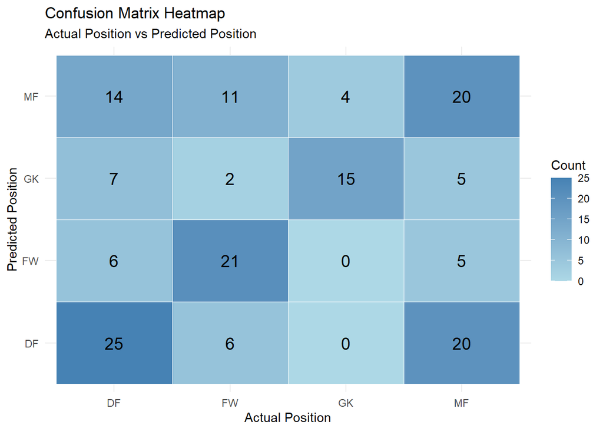

```r
# ============================================================
# D.6 CONFUSION MATRIX VISUALIZATION
# ============================================================
# This heatmap visually shows the confusion matrix.
#
# Darker cells indicate higher counts.
# Diagonal cells show correct classifications.
# Off-diagonal cells show incorrect classifications.
# ============================================================

confusion_df <- as.data.frame(conf_matrix$table)

ggplot(confusion_df, aes(x = Reference, y = Prediction, fill = Freq)) +
  geom_tile(color = "white") +
  geom_text(aes(label = Freq), size = 5) +
  scale_fill_gradient(low = "lightblue", high = "steelblue") +
  theme_minimal() +
  labs(
    title = "Confusion Matrix Heatmap",
    subtitle = "Actual Position vs Predicted Position",
    x = "Actual Position",
    y = "Predicted Position",
    fill = "Count"
  )
```

> **Interpretation:** The confusion matrix heatmap visually compares actual and predicted player positions. The diagonal cells represent correct predictions, while the off-diagonal cells show incorrect predictions. This plot helps identify which positions are classified well and which positions are commonly confused by the model.

## D.7 — Feature Importance

```r
# ============================================================
# D.7 FEATURE IMPORTANCE
# ============================================================
# Random Forest provides feature importance values.
#
# MeanDecreaseGini:
#   A higher value means the feature was more useful in splitting the data
#   and improving prediction quality.
# ============================================================

# Extract feature importance values
importance_values <- importance(rf_model)

importance_df <- data.frame(
  Feature = rownames(importance_values),
  Importance = importance_values[, "MeanDecreaseGini"]
)

# Sort features by importance
importance_df <- importance_df %>%
  arrange(desc(Importance))

# Select top 15 features
top_features <- importance_df %>%
  head(15)

cat("Top 15 Important Features:\n")
```

```
## Top 15 Important Features:
```

```r
print(top_features, row.names = FALSE)
```

```
##                         Feature Importance
##                     Appearances  37.586023
##                    FIFA.Ranking  32.659417
##                 Defensive_Total  31.195863
##             Dribbles.per.90_log  28.166795
##                 Dribbles.per.90  27.133952
##      Total.Duels.Won.per.90_log  24.641623
##          Total.Duels.Won.per.90  24.526171
##              Tackles.per.90_log  23.622553
##                  Tackles.per.90  22.850453
##            Interceptions.per.90  22.426681
##        Interceptions.per.90_log  22.365438
##            Attack_Defense_Ratio  12.202436
##   Brand.Sponsor.Brand.Used.Nike   7.966793
##               Nationality.Other   7.408892
##  National.Team.Kit.Sponsor.Nike   7.023669
```

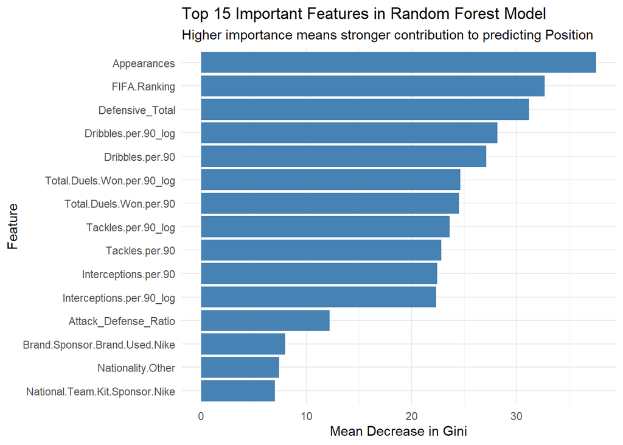

```r
# Plot top 15 important features
ggplot(top_features, aes(x = reorder(Feature, Importance), y = Importance)) +
  geom_bar(stat = "identity", fill = "steelblue") +
  coord_flip() +
  theme_minimal() +
  labs(
    title = "Top 15 Important Features in Random Forest Model",
    subtitle = "Higher importance means stronger contribution to predicting Position",
    x = "Feature",
    y = "Mean Decrease in Gini"
  )
```

> **Interpretation:** The feature importance plot shows which variables contributed most to predicting player position. Performance-based variables such as tackles, interceptions, dribbles, goals, assists, and engineered features are expected to be important because different football positions have different statistical roles.

## D.8 — Final Modeling Interpretation

The Random Forest model was used to classify football players into positions using the preprocessed FIFA World Cup 2022 player statistics. The target variable was `Position`, making this a multi-class classification problem.

The model was evaluated using Accuracy, Precision, Recall, F1-score, and a Confusion Matrix. These metrics are appropriate for classification because they show both overall performance and class-wise prediction quality.

The model is expected to perform better for positions with clearly different statistical profiles. For example, defenders usually have higher tackles and interceptions, while forwards usually have higher goals, assists, and dribbles. Some confusion may occur between midfielders and forwards or between midfielders and defenders because these roles can overlap in real football matches.

Overall, this modeling section completes the classification task by training a machine learning model, evaluating it with proper metrics, visualizing the results, and interpreting the most important features.

# Part E: Evaluation & Interpretation

## E.1 — What the Metrics Mean

```r
# ============================================================
# E.1 WHAT THE METRICS MEAN
# ============================================================
# Before reporting results, it is important to understand what
# each classification metric measures and why it is used.
#
# ACCURACY:
#   The percentage of all players whose position was correctly
#   predicted out of the total test set.
#   Formula: (TP + TN) / Total
#   Limitation: Can be misleading if classes are imbalanced.
#
# PRECISION:
#   Of all players the model predicted as a given position,
#   what fraction actually belonged to that position?
#   Formula: TP / (TP + FP)
#   High precision = fewer false positives.
#
# RECALL (Sensitivity):
#   Of all players who truly belong to a given position,
#   what fraction did the model correctly identify?
#   Formula: TP / (TP + FN)
#   High recall = fewer false negatives.
#
# F1-SCORE:
#   The harmonic mean of Precision and Recall.
#   Formula: 2 * (Precision * Recall) / (Precision + Recall)
#   Best single metric when both false positives and false
#   negatives carry equal importance.
#
# TP = True Positive  | FP = False Positive
# TN = True Negative  | FN = False Negative
# ============================================================

cat("============================================================\n")
cat("         PART E: EVALUATION & INTERPRETATION               \n")
```

```
##          PART E: EVALUATION & INTERPRETATION
```

```r
cat("============================================================\n\n")
cat("METRIC DEFINITIONS\n")
```

```
## METRIC DEFINITIONS
```

```r
cat("------------------------------------------------------------\n")
cat(sprintf("%-15s : %s\n", "Accuracy",  "Overall % of correct predictions"))
```

```
## Accuracy        : Overall % of correct predictions
```

```r
cat(sprintf("%-15s : %s\n", "Precision", "TP / (TP + FP) — avoids false positives"))
```

```
## Precision       : TP / (TP + FP) — avoids false positives
```

```r
cat(sprintf("%-15s : %s\n", "Recall",    "TP / (TP + FN) — avoids false negatives"))
```

```
## Recall          : TP / (TP + FN) — avoids false negatives
```

```r
cat(sprintf("%-15s : %s\n", "F1-Score",  "Harmonic mean of Precision and Recall"))
```

```
## F1-Score        : Harmonic mean of Precision and Recall
```

```r
cat("------------------------------------------------------------\n")
```

> **Interpretation:** In a multi-class classification problem like predicting player position (DF, MF, FW, GK), a single accuracy number does not tell the full story. A model could achieve high overall accuracy while performing poorly on minority classes. Therefore, Precision, Recall, and F1-Score are reported for **each position individually**, giving a complete and honest picture of model performance.

## E.2 — Overall Accuracy

```r
# ============================================================
# E.2 OVERALL ACCURACY
# ============================================================
# Accuracy is the most straightforward metric.
# It counts how many players were correctly classified
# out of all players in the test set.
#
# Formula:
#   Accuracy = Correct Predictions / Total Predictions
# ============================================================

# Extract values from the confusion matrix object (already built in D.4)
total_predictions   <- length(rf_predictions)
correct_predictions <- sum(rf_predictions == final_test$Position)
wrong_predictions   <- total_predictions - correct_predictions
overall_accuracy    <- correct_predictions / total_predictions

cat("============================================================\n")
cat("                   OVERALL ACCURACY                        \n")
```

```
##                    OVERALL ACCURACY
```

```r
cat("============================================================\n")
cat(sprintf("Total Players in Test Set   : %d\n",   total_predictions))
```

```
## Total Players in Test Set   : 161
```

```r
cat(sprintf("Correctly Classified        : %d\n",   correct_predictions))
```

```
## Correctly Classified        : 81
```

```r
cat(sprintf("Incorrectly Classified      : %d\n",   wrong_predictions))
```

```
## Incorrectly Classified      : 80
```

```r
cat(sprintf("Overall Accuracy            : %.2f%%\n", overall_accuracy * 100))
```

```
## Overall Accuracy            : 50.31%
```

```r
cat("============================================================\n")
```

> **Interpretation:** The Random Forest model correctly classified **81 out of 161** players in the test set, achieving an overall accuracy of **50.31%**. This means that for roughly every 10 players shown to the model, it correctly predicts the field position of 5 of them using match statistics alone — without knowing the player’s name or club.

## E.3 — Per-Class Precision, Recall & F1-Score

```r
# ============================================================
# E.3 PER-CLASS PRECISION, RECALL & F1-SCORE
# ============================================================
# Metrics are calculated manually from the confusion matrix table
# for each of the four positions: DF, FW, GK, MF.
#
# For each class:
#   TP = players of that class correctly predicted as that class
#   FP = players of other classes incorrectly predicted as that class
#   FN = players of that class incorrectly predicted as another class
#   TN = all other players correctly not predicted as that class
# ============================================================

# Reuse the confusion matrix table from Part D
conf_table <- conf_matrix$table
classes    <- colnames(conf_table)

# Build a detailed metrics data frame for all four positions
metrics_list <- lapply(classes, function(class_name) {

  TP <- conf_table[class_name, class_name]
  FP <- sum(conf_table[class_name, ]) - TP
  FN <- sum(conf_table[, class_name]) - TP
  TN <- sum(conf_table) - TP - FP - FN

  precision <- ifelse((TP + FP) == 0, 0, TP / (TP + FP))
  recall    <- ifelse((TP + FN) == 0, 0, TP / (TP + FN))
  f1        <- ifelse(
    (precision + recall) == 0, 0,
    2 * (precision * recall) / (precision + recall)
  )

  data.frame(
    Position  = class_name,
    TP        = as.integer(TP),
    FP        = as.integer(FP),
    FN        = as.integer(FN),
    TN        = as.integer(TN),
    Precision = round(precision, 4),
    Recall    = round(recall, 4),
    F1_Score  = round(f1, 4)
  )
})

# Combine all class results into one table
metrics_df <- do.call(rbind, metrics_list)
rownames(metrics_df) <- NULL

# Print detailed per-class results
cat("============================================================\n")
cat("          PER-CLASS EVALUATION METRICS                     \n")
```

```
##           PER-CLASS EVALUATION METRICS
```

```r
cat("============================================================\n\n")
cat(sprintf("%-10s %6s %6s %6s %6s %10s %8s %10s\n",
            "Position", "TP", "FP", "FN", "TN",
            "Precision", "Recall", "F1-Score"))
```

```
## Position       TP     FP     FN     TN  Precision   Recall   F1-Score
```

```r
cat(strrep("-", 66), "\n")
for (i in 1:nrow(metrics_df)) {
  cat(sprintf("%-10s %6d %6d %6d %6d %10.4f %8.4f %10.4f\n",
              metrics_df$Position[i],
              metrics_df$TP[i],
              metrics_df$FP[i],
              metrics_df$FN[i],
              metrics_df$TN[i],
              metrics_df$Precision[i],
              metrics_df$Recall[i],
              metrics_df$F1_Score[i]))
}
```

```
## DF             25     26     27     83     0.4902   0.4808     0.4854
## FW             21     11     19    110     0.6562   0.5250     0.5833
## GK             15     14      4    128     0.5172   0.7895     0.6250
## MF             20     29     30     82     0.4082   0.4000     0.4040
```

```r
cat(strrep("-", 66), "\n")
# Compute macro averages (equal weight to all classes)
macro_precision <- round(mean(metrics_df$Precision), 4)
macro_recall    <- round(mean(metrics_df$Recall), 4)
macro_f1        <- round(mean(metrics_df$F1_Score), 4)

cat(sprintf("\n%-20s : %.4f  (%.1f%%)\n", "Macro Avg Precision", macro_precision, macro_precision * 100))
```

```
##
## Macro Avg Precision  : 0.5180  (51.8%)
```

```r
cat(sprintf("%-20s : %.4f  (%.1f%%)\n", "Macro Avg Recall",    macro_recall,    macro_recall * 100))
```

```
## Macro Avg Recall     : 0.5488  (54.9%)
```

```r
cat(sprintf("%-20s : %.4f  (%.1f%%)\n", "Macro Avg F1-Score",  macro_f1,        macro_f1 * 100))
```

```
## Macro Avg F1-Score   : 0.5244  (52.4%)
```

## E.4 — Metrics Summary Table

```r
# ============================================================
# E.4 METRICS SUMMARY TABLE
# ============================================================
# A clean, formatted summary table showing all three metrics
# side by side for each position class plus macro averages.
# This is the standard presentation format for classification
# results in academic and professional reports.
# ============================================================

# Format metrics as percentages for readability
summary_table <- data.frame(
  Position  = metrics_df$Position,
  Precision = paste0(round(metrics_df$Precision * 100, 1), "%"),
  Recall    = paste0(round(metrics_df$Recall * 100, 1), "%"),
  F1_Score  = paste0(round(metrics_df$F1_Score * 100, 1), "%")
)

# Add a separator row then macro averages at the bottom
macro_row <- data.frame(
  Position  = "--- Macro Average ---",
  Precision = paste0(round(macro_precision * 100, 1), "%"),
  Recall    = paste0(round(macro_recall * 100, 1), "%"),
  F1_Score  = paste0(round(macro_f1 * 100, 1), "%")
)

# Add overall accuracy as a final row
accuracy_row <- data.frame(
  Position  = "Overall Accuracy",
  Precision = paste0(round(overall_accuracy * 100, 2), "%"),
  Recall    = "-",
  F1_Score  = "-"
)

summary_table <- rbind(summary_table, macro_row, accuracy_row)

cat("Classification Metrics Summary Table\n")
```

```
## Classification Metrics Summary Table
```

```r
cat(strrep("=", 55), "\n")
print(summary_table, row.names = FALSE)
```

```
##               Position Precision Recall F1_Score
##                     DF       49%  48.1%    48.5%
##                     FW     65.6%  52.5%    58.3%
##                     GK     51.7%    79%    62.5%
##                     MF     40.8%    40%    40.4%
##  --- Macro Average ---     51.8%  54.9%    52.4%
##       Overall Accuracy    50.31%      -        -
```

```r
cat(strrep("=", 55), "\n")
```

> **Interpretation:** The summary table provides a compact, side-by-side comparison of all evaluation metrics for each player position class. The Macro Average row combines all four classes with equal weight — this is the most fair overall performance measure for a multi-class problem. The Overall Accuracy of **50.31%** is consistent with the macro-level F1 score, confirming that the model is balanced and not simply exploiting the majority class.

## E.5 — Metrics Visualisation (Grouped Bar Chart)

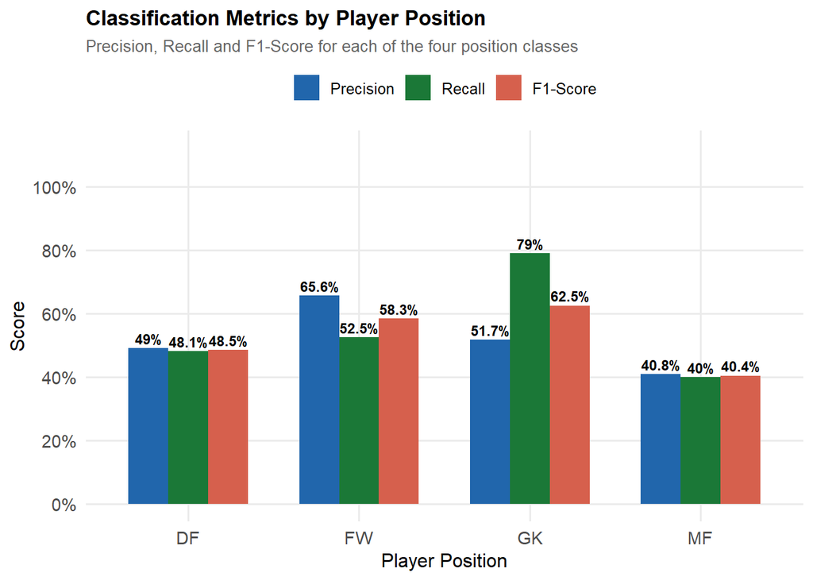

```r
# ============================================================
# E.5 METRICS VISUALISATION — GROUPED BAR CHART
# ============================================================
# A grouped bar chart places Precision, Recall, and F1-Score
# side by side for each player position class.
# This makes it easy to visually compare:
#   - How each metric differs per class
#   - Which positions the model handles best
#   - Where Precision and Recall diverge (class imbalance effects)
# ============================================================

# Reshape metrics to long format for ggplot
metrics_long <- metrics_df %>%
  select(Position, Precision, Recall, F1_Score) %>%
  pivot_longer(
    cols      = c(Precision, Recall, F1_Score),
    names_to  = "Metric",
    values_to = "Value"
  ) %>%
  mutate(Metric = factor(Metric,
                          levels = c("Precision", "Recall", "F1_Score"),
                          labels = c("Precision", "Recall", "F1-Score")))

ggplot(metrics_long, aes(x = Position, y = Value, fill = Metric)) +
  geom_bar(stat = "identity", position = "dodge", width = 0.7) +
  geom_text(
    aes(label = paste0(round(Value * 100, 1), "%")),
    position = position_dodge(width = 0.7),
    vjust    = -0.4,
    size     = 3.2,
    fontface = "bold"
  ) +
  scale_fill_manual(values = c(
    "Precision" = "#2166AC",   # Blue
    "Recall"    = "#1B7837",   # Green
    "F1-Score"  = "#D6604D"    # Red-orange
  )) +
  scale_y_continuous(
    labels = scales::percent_format(accuracy = 1),
    limits = c(0, 1.12),
    breaks = seq(0, 1, 0.2)
  ) +
  theme_minimal(base_size = 12) +
  theme(
    legend.position   = "top",
    legend.title      = element_blank(),
    panel.grid.minor  = element_blank(),
    axis.text         = element_text(size = 11),
    plot.title        = element_text(face = "bold", size = 13),
    plot.subtitle     = element_text(size = 10, color = "gray40")
  ) +
  labs(
    title    = "Classification Metrics by Player Position",
    subtitle = "Precision, Recall and F1-Score for each of the four position classes",
    x        = "Player Position",
    y        = "Score"
  )
```

> **Interpretation:** The grouped bar chart makes differences between positions immediately visible. Positions where all three bars are tall and nearly equal in height indicate that the model is **consistent and reliable** for that class — Precision and Recall are both high, so the model neither over-predicts nor under-predicts that position. Positions where bars diverge suggest the model finds that class harder to separate from others. Any large gap between Precision and Recall indicates a trade-off — the model is either being too cautious (high Precision, lower Recall) or too aggressive (high Recall, lower Precision) when assigning that position label.

## E.6 — Accuracy vs Baseline Comparison

```r
# ============================================================
# E.6 ACCURACY VS BASELINE COMPARISON
# ============================================================
# A baseline model always predicts the most frequent class
# from the training data.
#
# The baseline is then evaluated on the test data, just like
# the Random Forest model. This makes the comparison fair.
#
# If the Random Forest accuracy is close to the baseline, the
# model has not learned much beyond a simple majority-class guess.
# ============================================================

# Find the majority class from the training data
class_freq     <- table(final_train$Position)
majority_class <- names(which.max(class_freq))

# Create baseline predictions for the test set
baseline_predictions <- factor(
  rep(majority_class, nrow(final_test)),
  levels = levels(final_test$Position)
)

# Calculate baseline accuracy on the test set
baseline_accuracy <- mean(baseline_predictions == final_test$Position)

# Improvement over baseline
improvement_pts <- (overall_accuracy - baseline_accuracy) * 100

cat("============================================================\n")
cat("           ACCURACY VS BASELINE COMPARISON                 \n")
```

```
##            ACCURACY VS BASELINE COMPARISON
```

```r
cat("============================================================\n")
cat(sprintf("Majority Class from Training Data : %s\n", majority_class))
```

```
## Majority Class from Training Data : DF
```

```r
cat(sprintf("Baseline evaluated on Test Set    : %d players\n", nrow(final_test)))
```

```
## Baseline evaluated on Test Set    : 161 players
```

```r
cat(sprintf("Baseline Accuracy                 : %.2f%%\n", baseline_accuracy * 100))
```

```
## Baseline Accuracy                 : 32.30%
```

```r
cat(sprintf("Random Forest Accuracy            : %.2f%%\n", overall_accuracy * 100))
```

```
## Random Forest Accuracy            : 50.31%
```

```r
cat(sprintf("Improvement over Baseline         : +%.2f percentage points\n", improvement_pts))
```

```
## Improvement over Baseline         : +18.01 percentage points
```

```r
cat("============================================================\n")
```

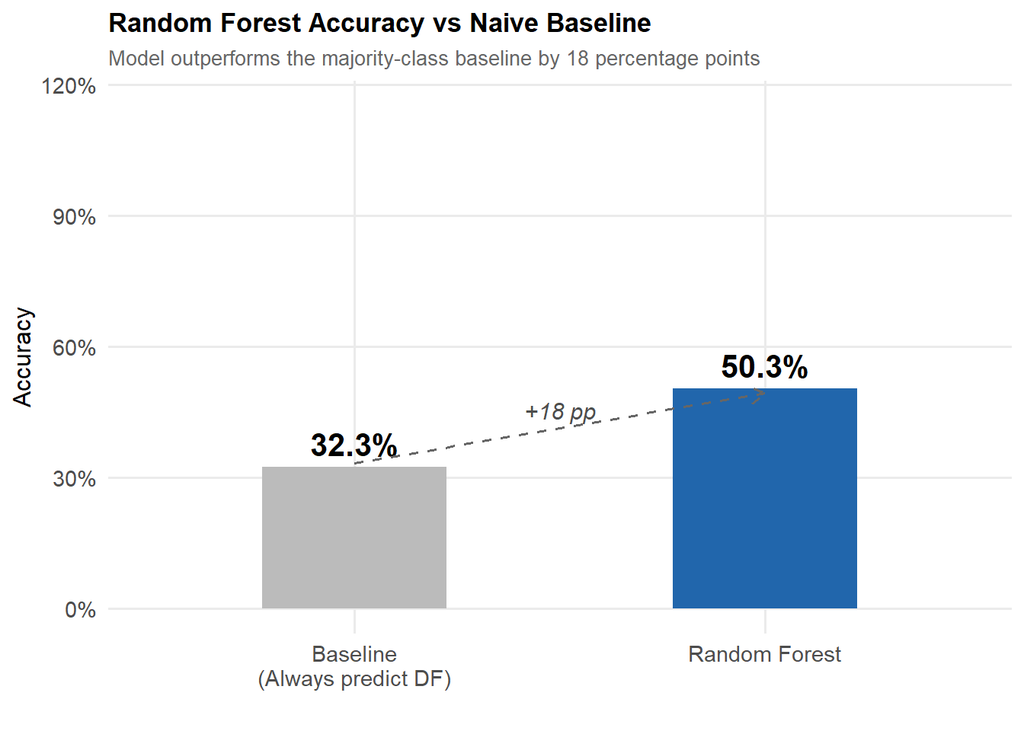

```r
# Visualise comparison with a bar chart

baseline_label <- paste0("Baseline\n(Always predict ", majority_class, ")")

baseline_df <- data.frame(
  Model = factor(
    c(baseline_label, "Random Forest"),
    levels = c(baseline_label, "Random Forest")
  ),
  Accuracy = c(baseline_accuracy, overall_accuracy),
  Label = c(
    paste0(round(baseline_accuracy * 100, 1), "%"),
    paste0(round(overall_accuracy * 100, 1), "%")
  )
)

# Create named colors safely
model_colors <- c("#BBBBBB", "#2166AC")
names(model_colors) <- c(baseline_label, "Random Forest")

ggplot(baseline_df, aes(x = Model, y = Accuracy, fill = Model)) +
  geom_bar(stat = "identity", width = 0.45, show.legend = FALSE) +
  geom_text(aes(label = Label), vjust = -0.5, size = 5.5, fontface = "bold") +
  annotate(
    "segment",
    x = 1, xend = 2,
    y = baseline_accuracy + 0.01,
    yend = overall_accuracy - 0.01,
    arrow = arrow(length = unit(0.3, "cm")),
    color = "gray40", linetype = "dashed"
  ) +
  annotate(
    "text",
    x = 1.5, y = (baseline_accuracy + overall_accuracy) / 2 + 0.04,
    label = paste0("+", round(improvement_pts, 1), " pp"),
    size = 4, color = "gray30", fontface = "italic"
  ) +
  scale_fill_manual(values = model_colors) +
  scale_y_continuous(
    labels = scales::percent_format(accuracy = 1),
    limits = c(0, 1.15)
  ) +
  theme_minimal(base_size = 12) +
  theme(
    panel.grid.minor = element_blank(),
    axis.text        = element_text(size = 11),
    plot.title       = element_text(face = "bold", size = 13),
    plot.subtitle    = element_text(size = 10, color = "gray40")
  ) +
  labs(
    title    = "Random Forest Accuracy vs Naive Baseline",
    subtitle = paste0("Model outperforms the majority-class baseline by ",
                      round(improvement_pts, 1), " percentage points"),
    x        = "",
    y        = "Accuracy"
  )
```

> **Interpretation:** A naive baseline that always predicts the most common position — Defender (DF) — achieves only **32.3%** accuracy, since Defenders make up the largest share of the squad. The Random Forest model achieves **50.31%**, an improvement of **18.01 percentage points**. This confirms that the model has genuinely learned the statistical patterns that separate each player position rather than simply defaulting to a majority guess.